# homework-3

Amina Mohammed (17301920), Joost Dijkstra (1251785),Edward Tandia (17310806)

14 November, 2022

#### Problem statement

The bootstrap is a straightforward method for estimating quantities for a statistic such as an estimator of its variance.

#### Exercise Solving

1. Using your most efficient implementation of the bootstrap from the previous homework, write a function named `bootstrap` with arguments `x` for a vector of sample data, `B` for the number of bootstrapped samples with default values `1000L` and `statistic` for a generic function to be passed. The function must return a list with the statistic evaluated on the sample `x`, say `theta_hat`, on the bootstrapped samples, say `theta_star`, and an estimate of the variance of the statistic, say `varBoot`.

My most efficient implementation of the bootstrap from the previous homework was the for loop. Based on this, I create function with 3 input: *data, B, Statistic* .

- *data* : is the data input
- *B* : is the number of bootstrapped samples with default values
- *Statistic* : is the statistcic which the user can selected. It has to be a function; either mean or variance.

the function `Bootstrap` will return 3 output: *theta_hat, theta_star, varBoot*

- *theta_hat* : is a list with the statistic evaluated on the sample
- *theta_star* : is a list with the statistic on the bootstrapped samples
- *varBoot* : is the estimate of the variance of the statistic.

I used for loops and multiple if conditioning in order to build my function.

2. Simulate a sample of size $10^4$ from a $t$-distribution with $\nu=3$ degrees of freedom (when $\nu\to\infty$, then the $t$-distribution tends to a standard normal distribution). Using the base R variance `var` as the `statistic`, compute the $B=1,000$ bootstrapped statistics using your function for subsamples of size $100$, $1,000$ and the full sample that you generated, and make three boxplots in one graph. The true variance is given by $\nu/(\nu-2)$. Illustrate it in your graph and comment what has been obtained. Does it illustrate some concepts in statistics or probability theory?

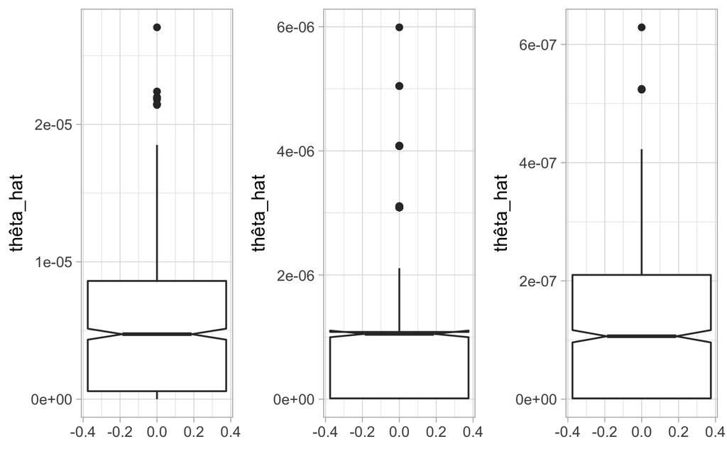

3. Take the one of the subsample of 2., and compare the performances between your implementation of `bootstrap` with the function bootstrap from the bootstrap package (installation required). Make sure the comparison is as fair as possible (same number of bootstrap samples, …).

In order to compare the performance of our implementation of `Bootstrap` we build to the function bootstrap from the bootstrap package. In order to make it as fair as possible, I’m going to take the subsample $1,000$ to have same number of bootstrap samples. Furthermore, I apply the same statistic to have also the same basis.

Note that I tried to use the subsample $100$, *Profvis produces error : No parsing data available. Maybe your function was too fast?* Thus I increase the subsample to $1,000$ to make the computation longer.

[interactive chart not shown]

Thus, the memory usage and computation time for the Bootstrap **using my function** are :  
-Memory usage : 27 MB  
-Computation time: 810 (ms)

And the memory usage and computation time for Bootstrap **using the function from R** are:  
-Memory usage : 0 MB  
-Computation time : 20 (ms)

Based on the profiling, we can see that the the computation time using my function is much higher that the case of using the function from R, however, these 2 functions are hardly comparable even though we use the same data as an input.

Indeed, `boot` from R package can return error, warning and different other messages, it is optimize and perfom much more than my computation. Theses different implementations increase the time of computing.

4. Load `test1.rds` and make this call `bootstrap(a, statistic = mean)`. The call must returns the following error: Error in bootstrap(a, statistic = mean) : ‘x’ must be numeric

In order to have this error message, I need to adapt my implementation by addition a section which will catch error on the type of the dataset I use for input. Indeed, I have use the function `stop` to have the error show and use a `if` to specify the typeof my input. Thus if the input isn’t numeric the error will show.

```
#> Error in Bootstrap(data = a, B = 1000L, Statistic = mean):  'x' must be numeric
```

5. Load `test2.rds` and execute `bootstrap(M, statistic = mean)`. The call must returns the following warning:

In order to have this warning message show, I need to adapt my implementation by addition a section which will catch changement which is apply on the input. Indeed the idea here is to treat `M` as a vector, this modification is call coercion. To do so I have use the function `warning` and modify my the data into a vector of dim NULL.

Thus this message will occur and the code will continue to RUN.

```
#> Warning in Bootstrap(M, B = 1000L, Statistic = mean): 'x' has been
#> coerced to a vector
```

6. Modify your implementation of `bootstrap` so `bootstrap(M, B="a", statistic = mean)` shows the following error: Error in bootstrap(M, B = “a”, statistic = mean) : ‘B’ must be numeric

In order to have this error message, I need to adapt my implementation by addition a section which will catch error on the type of the dataset I use for input. Indeed, I have use the function `stop` to have the error show and use a `if` to specify the typeof B is not a numeric.

Thus if the input isn’t numeric the error will show.

```
#> Error in Bootstrap(M, B = "a", Statistic = mean):  'B' must be numeric
```

7. Modify your implementation of `bootstrap` so `bootstrap(M, statistic = "mean")` shows the following error: Error in bootstrap(M, statistic = “mean”“) : ‘statistic’ must be a function

In order to have this error message, I need to adapt the implementation of the statistic. Indeed, I have use the function `stop` to have the error show and use a `if` to specify the typeof statistic is not a function. To make easier i run the following condition: (Statistic != “var” | Statistic != “mean” ).

Thus if the statistic isn’t a function the error will show.

```
#> Error in Bootstrap(mydata, B = 1000L, Statistic = "mean"):  'statistic' must be a function
```

8. Load `test3.rds` and see what happens when executing `bootstrap(m, statistic = mean)`. Remove any missing value from `m` and re-run the function calls. Removing missing values should happen within the function calls. The function `mean` has an argument for removing missing values, namely `mean(m, na.rm=TRUE)`. You are to exploit that, but `bootstrap(m, statistic = mean(na.rm = TRUE))` does not work (try it). Modify your implementation by using `...` as an argument in order for `bootstrap(m, statistic = mean, na.rm = TRUE)` to return the expected results.

After loading `test3.rds` , we can observe that there’s a lot of NA. In order to remove them within the function calls. I have added another input which I named `na.rm` it will work as a dummy variable. If TRUE, then we will omit the NA, if it’s FALSE we will include the NA in the calculation

[output not shown]

[output cut: 130 more lines]

### Problem 3

[output not shown]

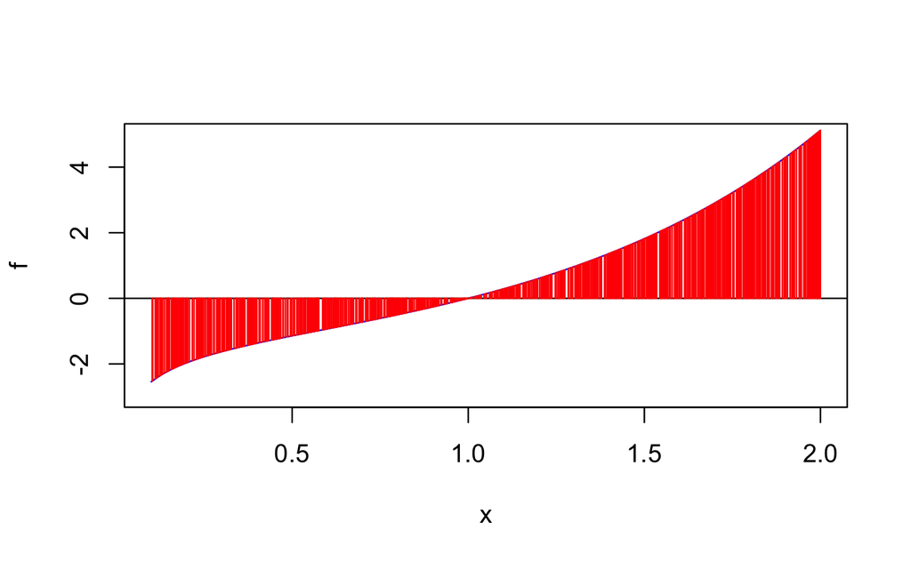